# Data exploration

2023-10-11

In this document, we will explore the data of two IMDB datasets, to answer our research question: ‘Does the run time of movies influence the average rating of that movie?’

## Summary of relevant variables

We are going to be looking at three different variables:

- **runtimeMinutes** from the title_basics dataset
- **titleType** from the title_basics dataset, as we will specificially look at movies later on.
- **averageRating** from the title_ratings dataset.

Next to that, we will some extra variables, that might be used as covariates in our analysis.

- **numVotes** from the title_ratings dataset
- **startYear** from the title_basics dataset

### titleType

First of all, the different types of titles are explored. This variable refers to the type/format of the title (e.g. movie, short, tvseries, tvepisode, video etc).

```r
summary(title_basics$titleType)
```

```
##    Length     Class      Mode
##  10204071 character character
```

```r
head(title_basics$titleType)
```

```
## [1] "short" "short" "short" "short" "short" "short"
```

```r
tail(title_basics$titleType)
```

```
## [1] "tvEpisode" "tvEpisode" "tvEpisode" "tvEpisode" "short"     "tvEpisode"
```

```r
table(title_basics$titleType)
```

```
##
##        movie        short    tvEpisode tvMiniSeries      tvMovie      tvPilot
##       658476       954007      7777520        50595       143109            1
##     tvSeries      tvShort    tvSpecial        video    videoGame
##       249891        10030        43490       280963        35989
```

As can be read from the output, there are 11 different types of titles. For the type ‘movie’, there are 658,476 observations.

### RuntimeMinutes

Second of all, the run time is explored. As the name suggests, this variable refers to the primary run time of the title, in minutes.

```r
summary(title_basics$runtimeMinutes)
```

```
##    Length     Class      Mode
##  10204071 character character
```

```r
head(title_basics$runtimeMinutes)
```

```
## [1] "1"  "5"  "4"  "12" "1"  "1"
```

```r
tail(title_basics$runtimeMinutes)
```

```
## [1] "\\N" "\\N" "\\N" "\\N" "27"  "10"
```

```r
min(title_basics$runtimeMinutes)
```

```
## [1] "\\N"
```

```r
max(title_basics$runtimeMinutes)
```

```
## [1] "Talk-Show"
```

```r
title_basics %>%
  group_by(runtimeMinutes) %>%
  count("\\N")
```

```
## # A tibble: 900 × 3
## # Groups:   runtimeMinutes [900]
##    runtimeMinutes `"\\\\N"`     n
##    <chr>          <chr>     <int>
##  1 0              "\\N"         5
##  2 1              "\\N"     21677
##  3 10             "\\N"     61915
##  4 100            "\\N"     16363
##  5 1000           "\\N"         6
##  6 1005           "\\N"         2
##  7 10062          "\\N"         1
##  8 1008           "\\N"         1
##  9 1009           "\\N"         1
## 10 101            "\\N"      5077
## # ℹ 890 more rows
```

### Average Rating

Next, the variable ‘averageRating’ is explored, which can be found in the ‘title_ratings’ dataset. The average rating is the weighted average of all individual user ratings.

```r
summary(title_ratings$averageRating)
```

```
##    Min. 1st Qu.  Median    Mean 3rd Qu.    Max.
##   1.000   6.200   7.200   6.959   7.900  10.000
```

```r
head(title_ratings$averageRating)
```

```
## [1] 5.7 5.8 6.5 5.5 6.2 5.0
```

```r
tail(title_ratings$averageRating)
```

```
## [1] 8.6 7.6 7.0 7.2 8.8 8.2
```

```r
mean(title_ratings$averageRating)
```

```
## [1] 6.958713
```

```r
table(title_ratings$averageRating)
```

```
##
##     1   1.1   1.2   1.3   1.4   1.5   1.6   1.7   1.8   1.9     2   2.1   2.2
##  1105   279   378   276   411   435   473   453   518   534   688   697   899
##   2.3   2.4   2.5   2.6   2.7   2.8   2.9     3   3.1   3.2   3.3   3.4   3.5
##   887  1106  1101  1303  1234  1702  1350  2071  1788  2496  2320  2689  2703
##   3.6   3.7   3.8   3.9     4   4.1   4.2   4.3   4.4   4.5   4.6   4.7   4.8
##  3343  3235  4133  3530  4962  4294  6203  5567  6710  6424  8216  7658  9919
##   4.9     5   5.1   5.2   5.3   5.4   5.5   5.6   5.7   5.8   5.9     6   6.1
##  8215 11956 10228 14574 13103 16051 15137 18586 17831 23035 19201 26718 23229
##   6.2   6.3   6.4   6.5   6.6   6.7   6.8   6.9     7   7.1   7.2   7.3   7.4
## 31110 27279 32487 30303 36023 33389 42265 35016 46689 39783 50714 43561 48493
##   7.5   7.6   7.7   7.8   7.9     8   8.1   8.2   8.3   8.4   8.5   8.6   8.7
## 44174 48541 42275 47627 36743 43061 32656 36490 26636 26120 21307 20798 16297
##   8.8   8.9     9   9.1   9.2   9.3   9.4   9.5   9.6   9.7   9.8   9.9    10
## 16395 11604 12981  7949  9487  5653  6129  3808  4224  2763  3042  1444  6845
```

Looking at the output, the range for ‘averageRating’ is 1-10.There seem to be no missing values.

### numVotes

We will explore the number of votes per title type as well, as this is highly related to the average rating that is given.

```r
summary(title_ratings$numVotes)
```

```
##    Min. 1st Qu.  Median    Mean 3rd Qu.    Max.
##       5      11      26    1040     101 2802850
```

```r
head(title_ratings$numVotes)
```

```
## [1] 1996  268 1883  177 2669  182
```

```r
tail(title_ratings$numVotes)
```

```
## [1]  6 11 22 36  6  6
```

As can be seen in the output, there is quite some fluctuation in the amount of reviews that a title gets. This is relevant information to take into account, as it will directly influence the reliability of the average rating.

### startYear

The start year represents the year in which the title was first released.

```r
summary(title_basics$startYear)
```

```
##    Length     Class      Mode
##  10204071 character character
```

```r
min(title_basics$startYear)
```

```
## [1] "\\N"
```

```r
max(title_basics$startYear)
```

```
## [1] "2031"
```

```r
unique(title_basics$startYear)
```

```
##   [1] "1894" "1892" "1893" "1895" "1896" "1898" "1897" "1900" "1899" "1901"
##  [11] "1902" "1903" "1905" "1904" "1912" "1907" "1906" "1908" "1910" "1909"
##  [21] "\\N"  "1990" "1914" "1911" "1913" "1915" "1919" "1916" "1917" "1918"
##  [31] "1936" "1925" "1920" "1922" "1921" "1923" "1924" "1928" "2019" "2021"
##  [41] "1926" "1927" "1929" "2000" "1993" "1935" "1930" "1942" "1934" "1931"
##  [51] "1932" "1939" "1937" "1933" "1950" "1938" "1951" "1945" "1946" "1940"
##  [61] "1944" "1949" "1947" "1941" "1952" "1970" "1957" "1943" "1959" "1948"
##  [71] "2001" "1994" "1953" "1954" "1965" "1983" "1980" "1973" "1961" "1995"
##  [81] "1955" "1962" "1958" "1956" "1960" "1977" "1964" "2012" "1967" "1968"
##  [91] "1963" "1988" "1986" "1971" "1969" "1972" "1966" "1976" "1979" "2016"
## [101] "2020" "1974" "1978" "1981" "1975" "1989" "2014" "1985" "1987" "2010"
## [111] "2018" "1984" "1992" "2023" "1982" "1991" "2022" "2008" "1999" "2005"
## [121] "2003" "1998" "2002" "1997" "2009" "2004" "1996" "2017" "2006" "2013"
## [131] "2015" "2007" "2011" "1891" "2024" "1888" "1890" "1889" "2025" "2026"
## [141] "2027" "1878" "2030" "2028" "1877" "1882" "1881" "1887" "2029" "1874"
## [151] "1883" "2031" "1885"
```

The output shows that the titles fall in the range of 1874-2031. This means that the data set also contains titles of movies that have not been released, or that there needs to be some data cleaning done.

## Generating plots

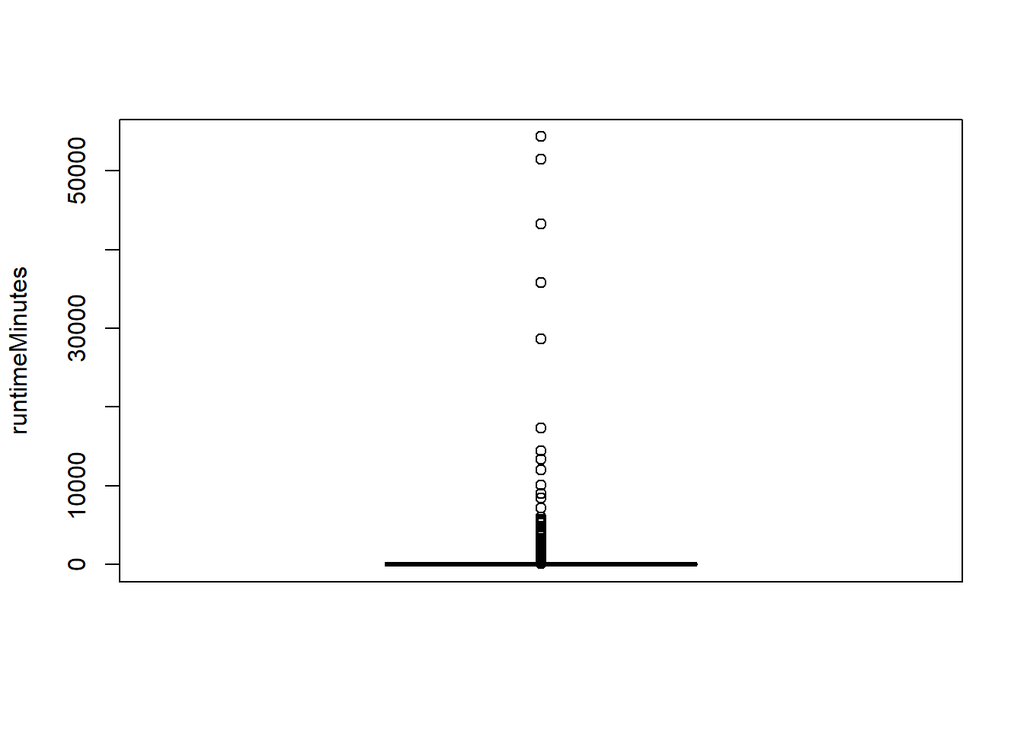

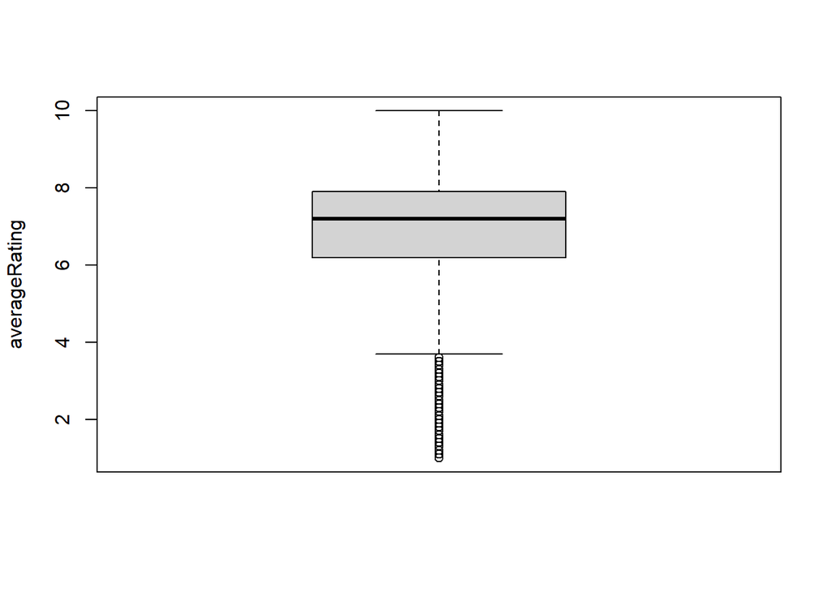

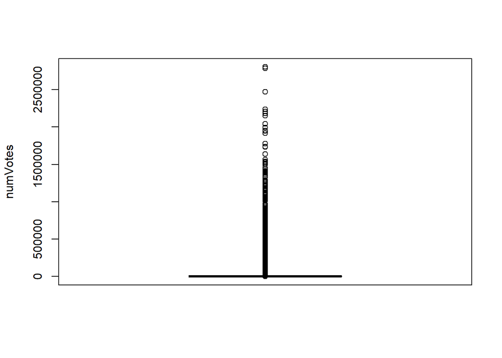

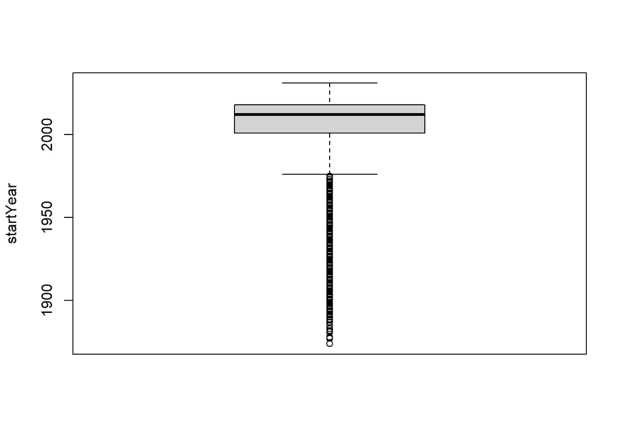

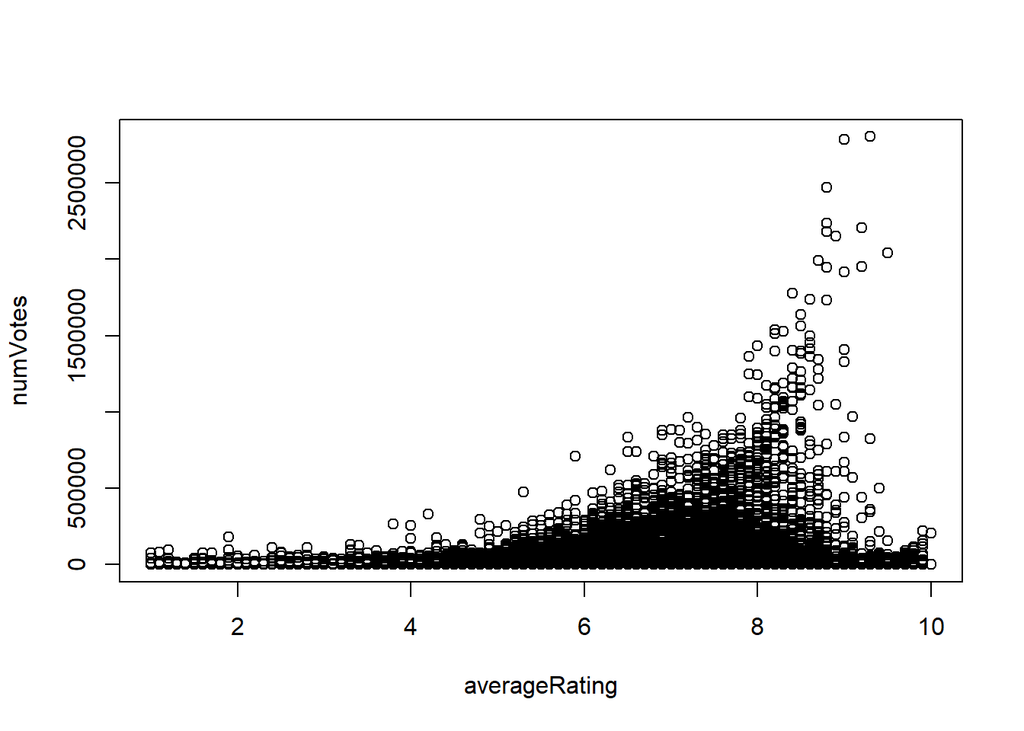

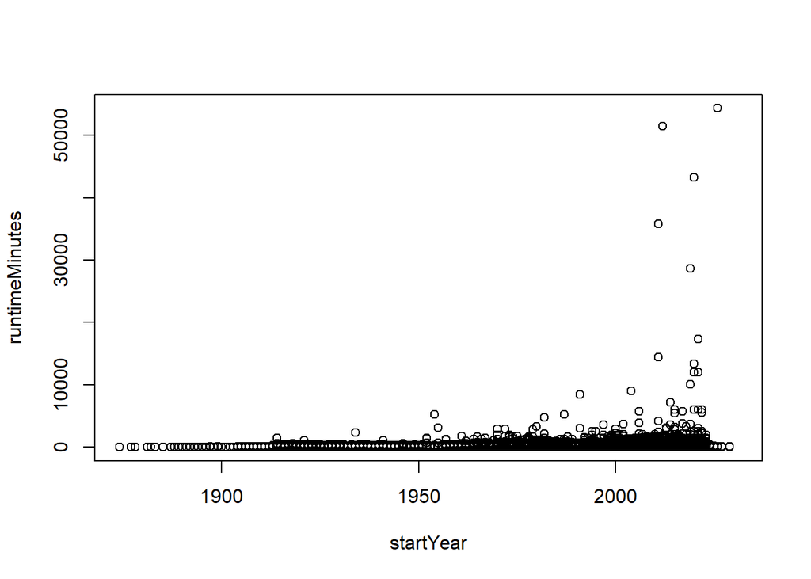

The boxplot that visualizes the variable ‘runtimeMinutes’ shows that there are a few outliers. These observations include movies that are over 30,000 minutes long (or more than 20 days). For the number of votes (numVotes) and the average rating (averageRating) we do not identify any problematic outliers.

The scatterplot between the average rating and the number of votes indicates a positive relationship between the two variables. This relationship, however, is not linear. Due to the outliers in the runtime variable, it is difficult to identify a relationship between the startYear and runtimeMinutes variables.